# Quantification

A missing value in this data usually means the protein was too faint to detect, not that it was absent at random. limpa turns that into a model: one detection probability curve for the whole experiment, then a value and a standard error for every protein in every run. Observed values keep a small standard error; values the curve had to estimate get a wide one, so later fits weight them less. Nothing is filled in as if it had been measured.

This step writes three objects. `proteins.rds` holds limpa’s fit for the protein-level models, which carry blood as a covariate. `DAList_limpa.rds` holds the complete matrix. `DAList_corrected.rds` holds the same matrix with each protein’s blood slope removed, for methods that cannot carry a covariate.

## Packages

```r
library(here)
library(limma)
library(limpa)
library(dplyr)
library(tibble)
source(here("00_Setup", "Shared_functions", "analysis_reporting_helpers.R"))
```

## Input

The input is the normalised `DAList`: log2 abundance with `NA` where a protein went undetected. `blood_rel`, the run’s haemoglobin signal relative to its median intensity, comes from `01_Protein_Filtering`. Centring it (`blood`) makes the model intercepts refer to a run of average blood content.

```r
stage <- here("01_Processing", "03_Quantification")
out <- file.path(stage, "c_data")
dir.create(out, recursive = TRUE, showWarnings = FALSE)
inputs <- c(normalized = "01_Processing/02_Normalisation/c_data/DAList_normalized.rds")
paths <- vapply(inputs, here, character(1))
stopifnot(file.exists(paths))
dal <- readRDS(paths[["normalized"]])
values <- as.matrix(dal$data)
stopifnot(identical(dal$metadata$sample_id, colnames(values)))

group_time_levels <- c("HR_T1", "HR_T2", "HR_T3", "LR_T1", "LR_T2", "LR_T3")
meta <- as_tibble(dal$metadata) |>
  mutate(group_time = factor(group_time, group_time_levels), blood = blood_rel - mean(blood_rel))
dim(values)
```

```
[1] 1900   45
```

```r
c(pct_missing = round(100 * mean(is.na(values)), 1))
```

```
pct_missing
       12.3
```

```r
head(select(meta, sample_id, subject, group_time, blood_rel, blood))
```

```
# A tibble: 6 × 5
  sample_id subject group_time blood_rel  blood
  <chr>     <chr>   <fct>          <dbl>  <dbl>
1 S03_T1    HR_S03  HR_T1           10.4 -1.31
2 S10_T1    HR_S10  HR_T1           10.6 -1.04
3 S16_T1    HR_S16  HR_T1           12.7  1.07
4 S22_T1    HR_S22  HR_T1           10.5 -1.20
5 S24_T1    HR_S24  HR_T1           11.8  0.138
6 S27_T1    HR_S27  HR_T1           11.5 -0.191
```

## Detection probability curve

`dpc()` fits the chance that a value is detected as a logistic function of its log2 intensity: the intercept sets where detection starts, the slope how fast it rises. A slope near 0 would mean values go missing at random; a steep slope means faint proteins go missing first.

Evidence for this route (decisions log, 2026-10-01): missingness here tracks intensity (Spearman rho -0.77), and the earlier pipeline’s imputation (missForest) filled mid-range values and shrank the variance. 17 of 49 earlier interaction hits rested on a group cell with 3 or fewer observed values.

```r
curve <- dpc(values)
curve$dpc
```

```
      beta0       beta1
-10.4520508   0.6691848
```

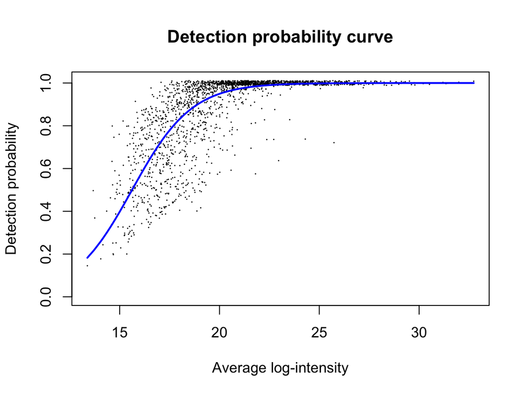

Figure 1: Detection probability against log2 intensity. The curve is limpa’s fit.

```r
plotDPC(curve)
```

## A value and a standard error for every protein

The input is already summarised to proteins, so each row is its own feature. `dpcQuantByRow()` is the route the limpa vignette gives for protein-level input, and Gordon Smyth confirmed on the Bioconductor support site (support.bioconductor.org/p/9163224) that it needs intensity-based log values, which this matrix is.

```r
proteins <- dpcQuantByRow(values, dpc = curve, verbose = FALSE)
observed <- proteins$other$n.observations > 0
stopifnot(!anyNA(proteins$E), identical(observed, !is.na(values)))
standard_error <- proteins$other$standard.error
```

One protein with gaps, before and after. Observed runs keep their value and a small standard error; the missing runs get an estimate from the curve and a wide standard error.

```r
example <- which(rowSums(!observed) >= 3)[1]
tibble(
  sample_id = colnames(values)[1:8],
  observed = round(values[example, 1:8], 2),
  limpa = round(proteins$E[example, 1:8], 2),
  standard_error = round(standard_error[example, 1:8], 2)
) |>
  print(n = 8)
```

```
# A tibble: 8 × 4
  sample_id observed limpa standard_error
  <chr>        <dbl> <dbl>          <dbl>
1 S03_T1        NA    16.1           0.8
2 S10_T1        NA    16.1           0.8
3 S16_T1        NA    16.1           0.8
4 S22_T1        NA    16.1           0.8
5 S24_T1        16.8  16.8           0.01
6 S27_T1        NA    16.1           0.8
7 S28_T1        17.2  17.2           0.01
8 S04_T1        16.6  16.6           0.01
```

```r
c(protein = dal$annotation$gene[example], runs_missing = sum(!observed[example, ]))
```

```
     protein runs_missing
     "ESYT2"         "21"
```

## Blood-corrected matrix

Some methods (gene-set scores, co-expression modules, clustering) take no covariate. For them, each protein’s slope on the blood index is removed with `limma::removeBatchEffect()`. The slope is fitted beside time point only, `~ 0 + timepoint`, so no HR or LR label shapes the matrix every later analysis reads. Models that can carry blood as a covariate use `proteins.rds` instead (decisions log, 2026-10-01).

```r
corrected <- remove_blood_effect(proteins$E, meta$blood, model.matrix(~ 0 + timepoint, meta))
```

Each protein’s Spearman correlation with the blood index, before and after removal, split by how many of the 45 runs measured the protein.

```r
blood_rho <- \(m) as.vector(cor(t(m), meta$blood, method = "spearman"))
tibble(
  runs_measured = cut(rowSums(observed), c(0, 10, 20, 39, 45)),
  before = abs(blood_rho(proteins$E)), after = abs(blood_rho(corrected))
) |>
  group_by(runs_measured) |>
  summarise(proteins = n(), median_rho_before = median(before), median_rho_after = median(after))
```

```
# A tibble: 4 × 4
  runs_measured proteins median_rho_before median_rho_after
  <fct>            <int>             <dbl>            <dbl>
1 (0,10]               6             0.209           0.599
2 (10,20]             79             0.121           0.332
3 (20,39]            526             0.133           0.116
4 (39,45]           1289             0.144           0.0834
```

Removal works for well-measured proteins and fails for sparse ones: it raises their correlation with blood. The likely cause is that `removeBatchEffect()` fits one slope across measured and curve-estimated values, then subtracts slope × blood from both, stamping blood onto estimates that never carried it. This is an open methodological problem, not yet fixed. Every analysis that reads `DAList_corrected.rds` inherits it for proteins measured in few runs.

## Validation

```r
stopifnot(
  identical(dim(proteins$E), dim(values)),
  identical(dim(corrected), dim(values)),
  !anyNA(corrected),
  all(standard_error > 0),
  identical(meta$sample_id, colnames(corrected))
)
se_observed <- median(standard_error[observed])
se_missing <- median(standard_error[!observed])
c(median_se_observed = se_observed, median_se_missing = se_missing)
```

```
median_se_observed  median_se_missing
       0.009999256        0.802949371
```

## Summary

12.3% of values are missing. The detection curve has intercept -10.45 and slope 0.67 on the logit scale. 1900 proteins now have a value in all 45 runs; 931 were measured in every run, and the median protein in 44. A missing value’s median standard error is 80.3 times an observed one’s.

## Save

`proteins.rds` feeds the protein-level contrasts. `DAList_limpa.rds` and `DAList_corrected.rds` feed the set, module, classification and trait steps. `05_Figures/Processing/S01_QC` reads the workbook. The `sample_correlation` sheet centres each protein on its mean first, so the correlation reflects how runs differ rather than the abundance order every run shares.

```r
as_dalist <- function(data) {
  list(data = data, annotation = dal$annotation, metadata = meta, observed = observed)
}
saveRDS(
  list(proteins = proteins, metadata = meta, annotation = dal$annotation),
  file.path(out, "proteins.rds"),
  compress = "xz"
)
saveRDS(as_dalist(proteins$E), file.path(out, "DAList_limpa.rds"), compress = "xz")
saveRDS(as_dalist(corrected), file.path(out, "DAList_corrected.rds"), compress = "xz")

write_workbook(
  list(
    curve = tibble(
      term = names(curve$dpc), estimate = unname(curve$dpc),
      pct_missing = 100 * mean(!observed)
    ),
    proteins = tibble(
      uniprot_id = rownames(values), gene = dal$annotation$gene,
      n_observed = rowSums(observed), prop_observed = rowMeans(observed),
      mean_observed = rowMeans(values, na.rm = TRUE), mean_complete = rowMeans(proteins$E),
      median_se_observed = apply(ifelse(observed, standard_error, NA), 1, median, na.rm = TRUE),
      median_se_missing = apply(ifelse(observed, NA, standard_error), 1, median, na.rm = TRUE)
    ),
    blood = select(meta, sample_id, subject, group_time, blood_rel, blood),
    sample_correlation = as_tibble(cor(corrected - rowMeans(corrected)), rownames = "sample_id")
  ),
  c(
    "DPC intercept and slope on the logit scale, and the share of values missing.",
    paste(
      "Per protein: values observed, mean log2 abundance where observed and over the complete",
      "matrix, and the median standard error where observed and where missing."
    ),
    "Per sample: blood index (HBB and HBA1 against the sample median) and its centred value.",
    "Pearson correlation between samples, each protein centred, on the blood-corrected matrix."
  ),
  file.path(out, "quantification.xlsx"),
  inputs, paths
)
```